# Mussels and Sea Stars

# The Data

This project seeks to compare the abundance of sea star *Pisaster ochraceus* and local mussels species in rocky intertidal zones across the US West coast. This project focuses on abundance data before and after a breakout of Sea Star Wasting Syndrome (SSWS).

Packages required :

- Tidyverse
- Knitr
- kableExtra

The data set used is from [Sea Star Wasting Syndrome impacts to intertidal communities via mass mortality of a keystone predator](https://figshare.com/articles/dataset/Data_for_Sea_Star_Wasting_Syndrome_impacts_to_intertidal_communities_via_mass_mortality_of_a_keystone_predator_/9795584)

# The relationship between sea stars and mussels

The sea star *Pisaster ochraceus* is a key stone predator for intertidal communities. As a keystone predator these sea stars keep populations of competitively dominant species (mussels) in check. Some advantages of their role in intertidal communities include:

- Reducing competition for space
- Protecting populations of producers (i.e kelp) and their consumers
- Maintaining biodiversity

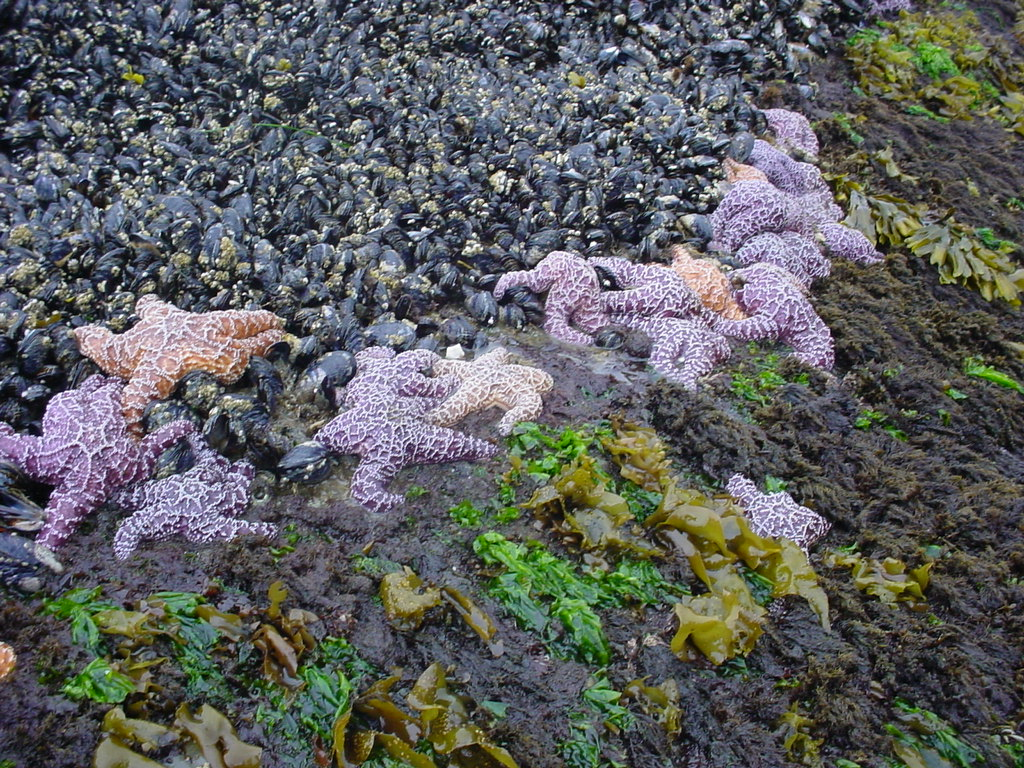

mussels

# Sea Star Wasting Syndrome (SSWS)

Though not much is known about the causes of SSWS, the disease can be fatal to sea stars and has been known to cause mass mortality. The disease begins with lesions and eventually deterioration of the sea star’s body, ending in death.

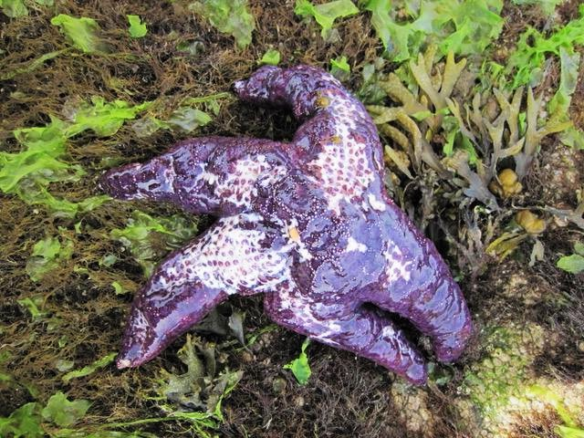

SSWS

# Reading in and Viewing the Data

| Site | Region | Time Relative to SSWS | Mussel Mean Percent Cover | Pisaster Mean Density |
| --- | --- | --- | --- | --- |
| Alegria | CA South | Post | 3.2450897 | 0.00100 |
| Alegria | CA South | Pre | 8.4506761 | 0.05025 |
| Andrew Molera | CA Central | Post | 3.1881804 | 0.08900 |
| Andrew Molera | CA Central | Pre | 0.4792557 | 0.08300 |
| Ano Nuevo | CA Central | Post | 2.8458498 | 0.00600 |
| Ano Nuevo | CA Central | Pre | 1.3506452 | 0.01400 |

# Comparing *Pisaster* density to Mussel percent cover

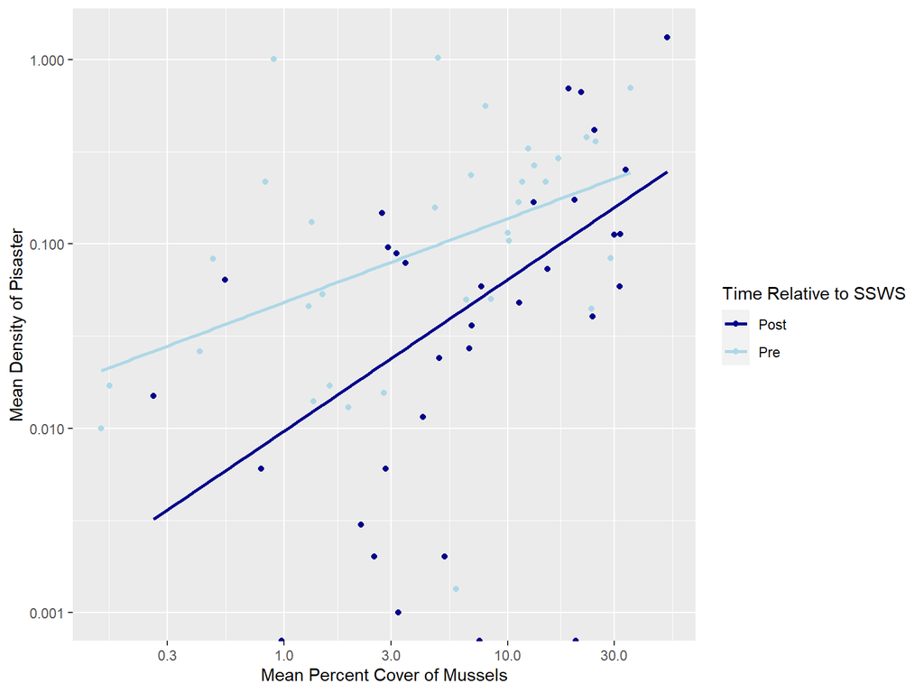

# Change in Mussel Cover by Region

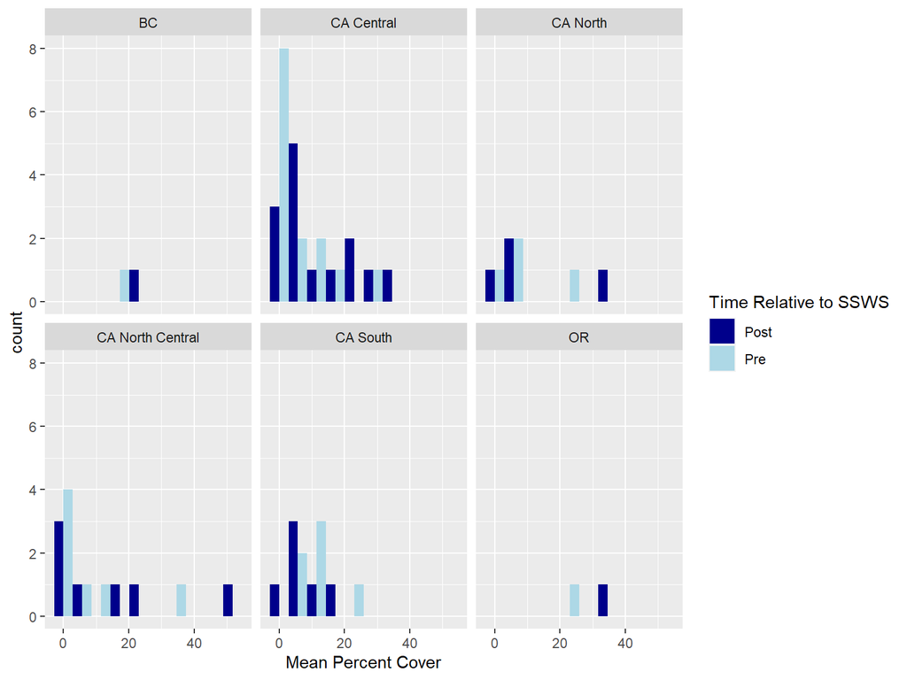

# Conclusion

- After the occurrence of Sea Star Wasting Disease, average *Pisaster* density decreased while average Mussel percent cover increased. This is most likely the result of *Pisaster’s* role as a keystone predator, without them mussels are left to out compete other species for space
- Some regions ,such as Southern California, saw a decrease in mussel cover post SSWS. This could be the results of regional environmental or biological factors.
- More research should be done to study the effect of SSWS on both *Pisaster* and other members of the rocky intertidal community.